# hw

### (c)

Confusion matrix is shown below

Overall fraction of correct predictions is 53.44%

In the confusion matrix, these numbers that are not on the diagonal denote the number of samples for the predicted error category. such as we predict 42 samples as Down which true labels are Up.

In a similar way, these numbers that are on the diagonal as model get them true labels.

```r
prep = predict(model1,data)
prep1 = ifelse(prep>0.5,'Down','Up')
t = table(prep1,data$Direction)
print(t)
```

```
##
## prep1  Down  Up
##   Down   19  42
##   Up    465 563
```

```r
acc = (t[1]+t[4])/length(rownames(data))
acc
```

```
## [1] 0.5344353
```

### (d)

Confusion matrix is shown below.

Overall fraction of correct predictions is 55.76%.

```r
train = data[which(data$Year>=1990 & data$Year<=2008),]
test = data[which(data$Year>2008),]
model2 = glm(Direction~Lag2,train,family = "binomial")
prep2 = predict(model2,test)
prep22 = ifelse(prep2>0.5,'Down','Up')
t = table(prep22,test$Direction)
print(t)
```

```
##
## prep22 Down Up
##   Down    2  5
##   Up     41 56
```

```r
acc = (t[1]+t[4])/length(rownames(test))
acc
```

```
## [1] 0.5576923
```

### (e)

Confusion matrix is shown below.

Overall fraction of correct predictions is 62.5%.

```r
library(MASS)
model3 = lda(Direction~Lag2,train,family = "binomial")
prep3 = predict(model3,test)
prep33 = prep3$class
t = table(prep33,test$Direction)
print(t)
```

```
##
## prep33 Down Up
##   Down    9  5
##   Up     34 56
```

```r
acc = (t[1]+t[4])/length(rownames(test))
acc
```

```
## [1] 0.625
```

### (f)

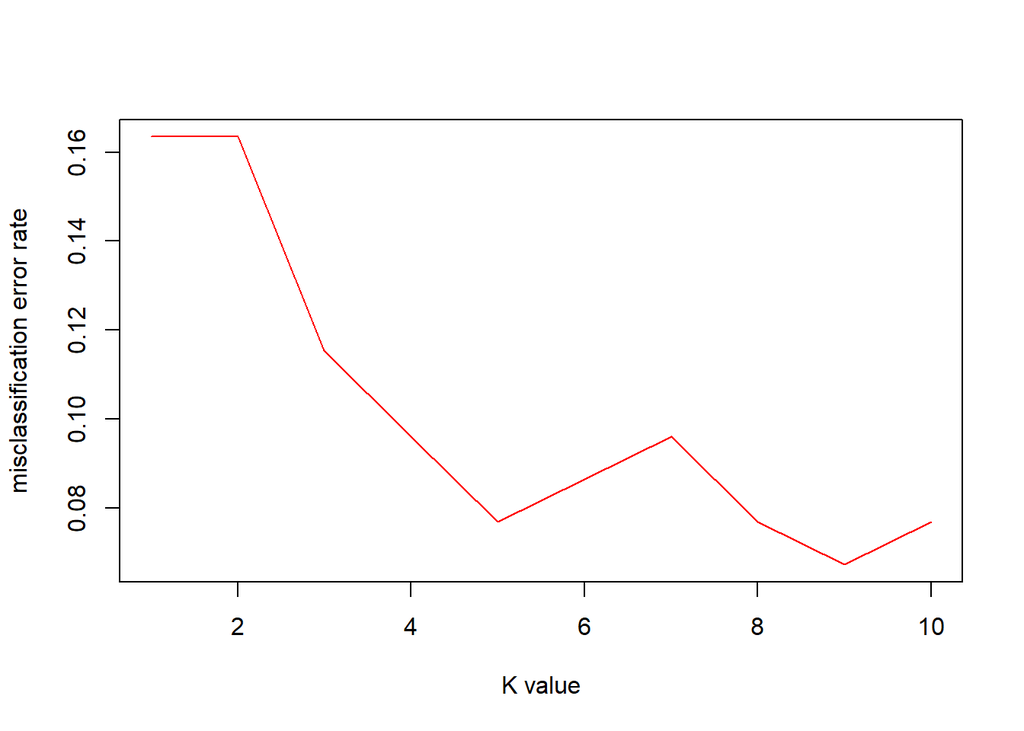

```r
library(class)
misl = c()
prepl = c()
for (k in 1:10){
  prep4<-knn(train=train[,2:8],test=test[,2:8],cl=train$Direction,k=k)
  prepl = append(prepl,prep4)
  t = table(prep4,test$Direction)
  mis = (t[2]+t[3])/length(rownames(test))
  misl = append(misl,mis)
}
plot(misl,type = 'l',col = 'red',ylab = 'misclassification error rate',xlab = 'K value')
```

### (h)

```r
library(ROCit)
```

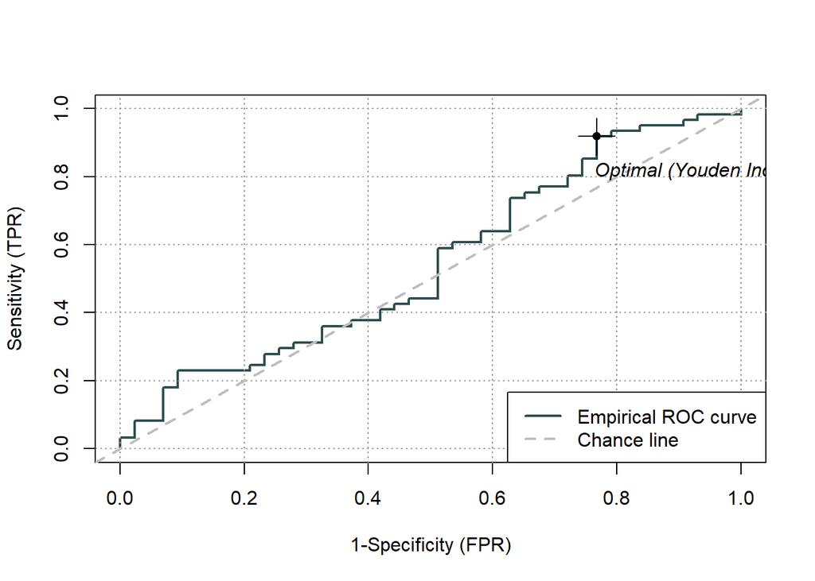

```r
a2 = rocit(score=prep2,class=test$Direction)
plot(a2)
a3 = rocit(score=as.vector(prep3$x),class=test$Direction)
plot(a3)
```

[output not shown]

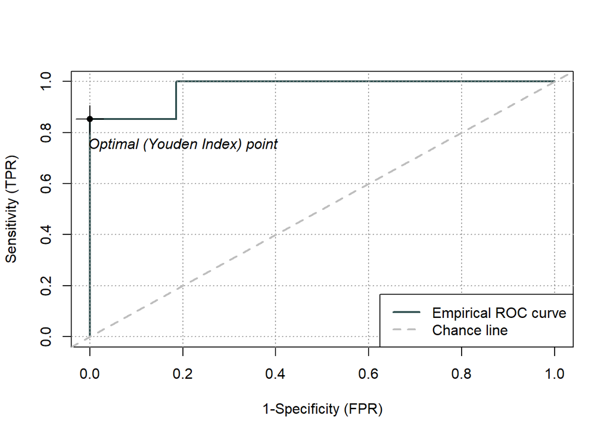

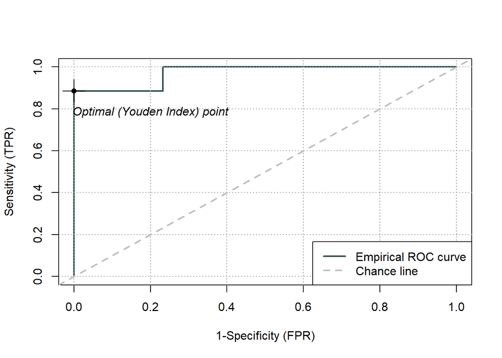

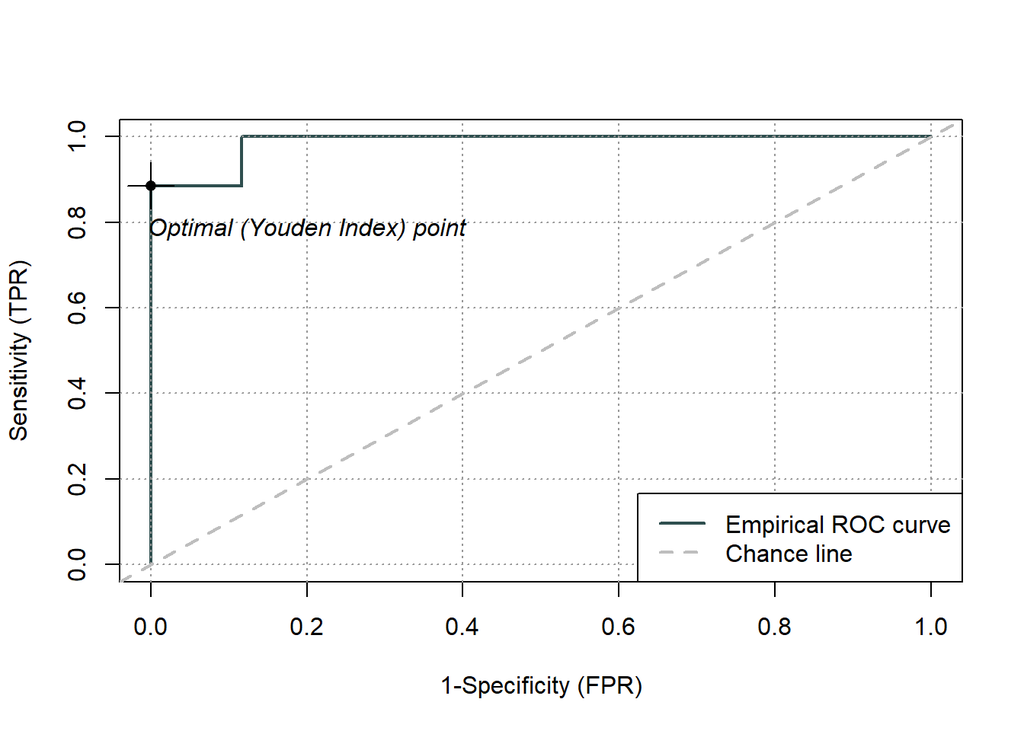

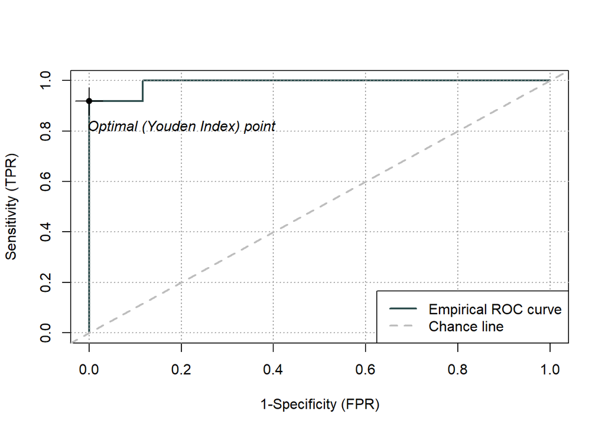

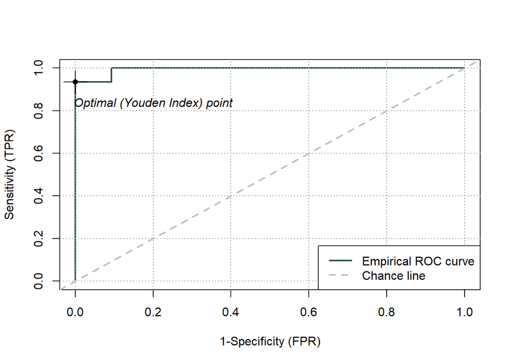

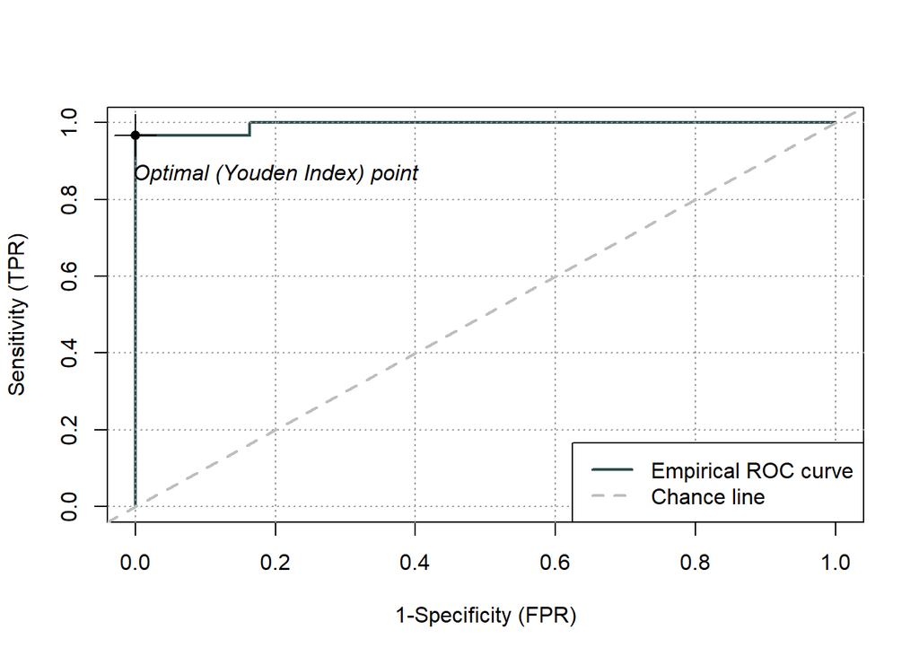

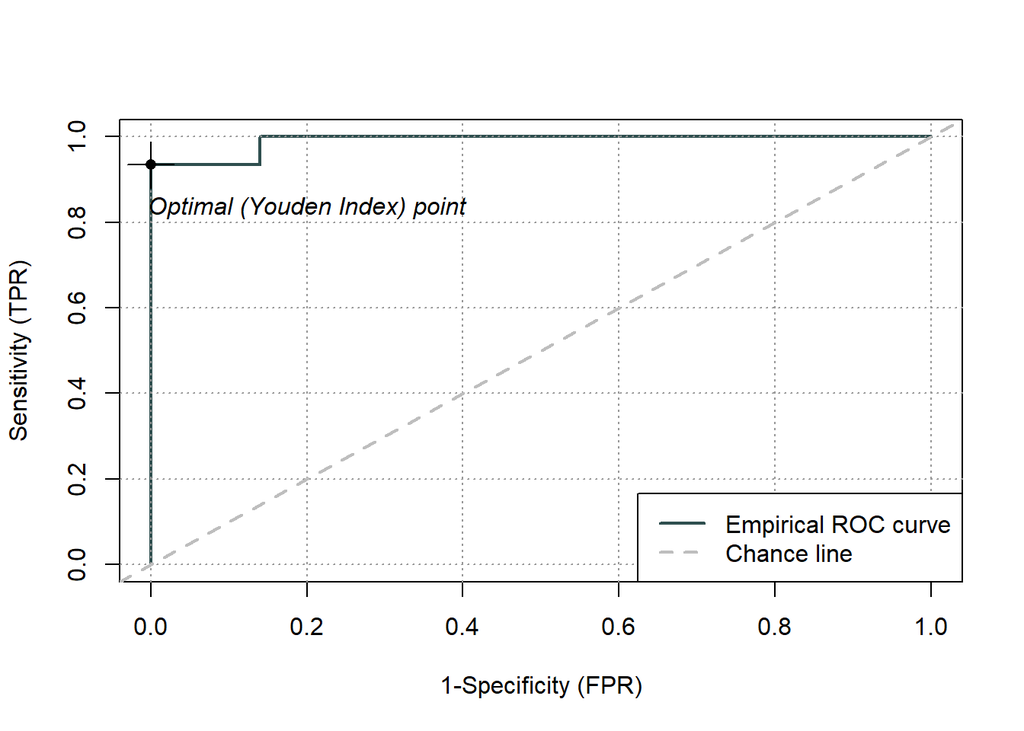

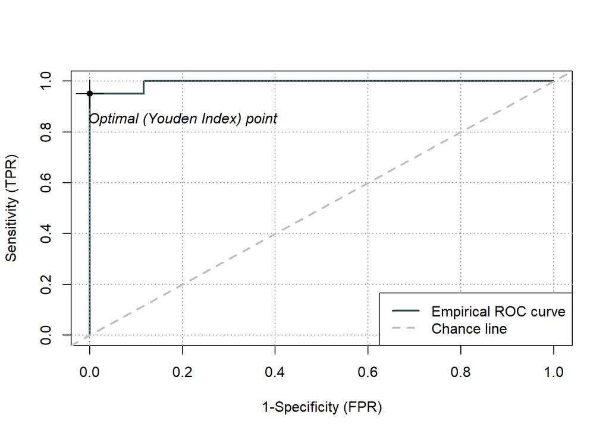

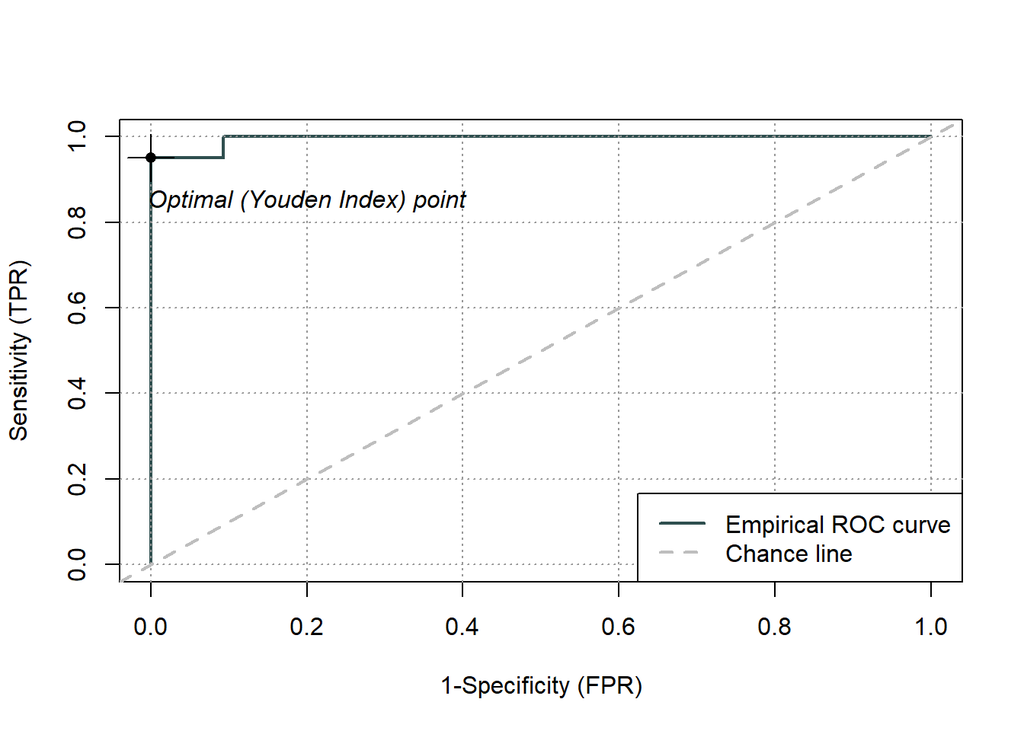

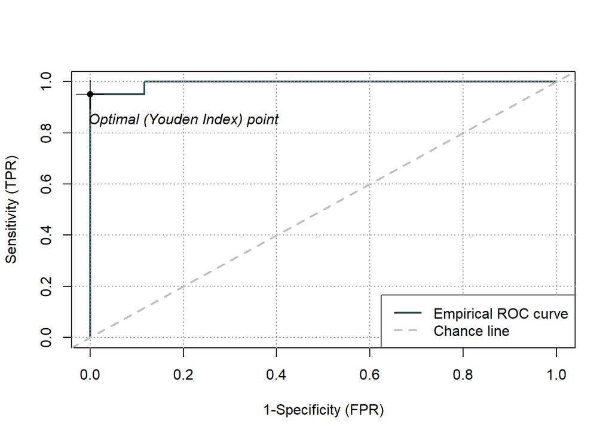

```r
for(k in 1:10){
  a4 = rocit(score=prepl[(1+104*(k-1)):(104*k)],class=test$Direction)
  plot(a4)
}
```